# About the project

# Exploring the predictive power of the model

```r
m <- glm(high_use ~ failures + absences + famrel + higher, data = alc, family = "binomial")

probabilities <- predict(m, type = "response")

alc <- mutate(alc, probability = probabilities)
alc <- mutate(alc, prediction = probability > 0.5)
select(alc, failures, absences, famrel, high_use, probability, prediction) %>% tail(10)
```

```
##     failures absences famrel high_use probability prediction
## 373        1        0      4    FALSE   0.2765114      FALSE
## 374        1        7      5     TRUE   0.3531843      FALSE
## 375        0        1      5    FALSE   0.1764851      FALSE
## 376        0        6      4    FALSE   0.2898242      FALSE
## 377        1        2      5    FALSE   0.2646186      FALSE
## 378        0        2      4    FALSE   0.2262058      FALSE
## 379        2        2      2    FALSE   0.5234763       TRUE
## 380        0        3      1    FALSE   0.3857482      FALSE
## 381        0        4      2     TRUE   0.3523118      FALSE
## 382        0        2      4     TRUE   0.2262058      FALSE
```

```r
table(high_use = alc$high_use, prediction = alc$prediction) %>% prop.table %>% addmargins()
```

```
##         prediction
## high_use      FALSE       TRUE        Sum
##    FALSE 0.65445026 0.04712042 0.70157068
##    TRUE  0.25392670 0.04450262 0.29842932
##    Sum   0.90837696 0.09162304 1.00000000
```

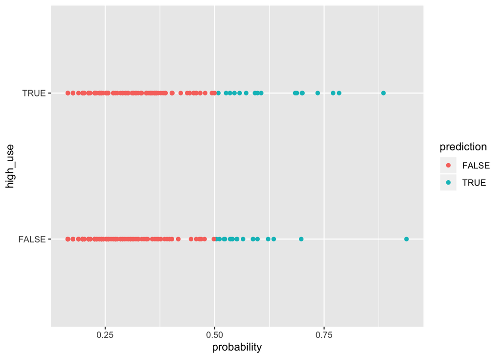

```r
g <- ggplot(alc, aes(x = probability, y = high_use, col = prediction))

g + geom_point()
```

# The training error

```r
loss_func <- function(class, prob) {
  n_wrong <- abs(class - prob) > 0.5
  mean(n_wrong)
}

loss_func(class = alc$high_use, prob = alc$probability)
```

```
## [1] 0.3010471
```

The training errors result is 0.30 meaning 30%. This means that almost 30% a.k.a 1/3 of observations are incorrectly classified. I do not know if this is very common when doing a model. I think the number is quite high and the model is not working as it should be working.

# Perform 10-fold cross validation on this model

```r
loss_func <- function(class, prob) {
  n_wrong <- abs(class - prob) >0.5
  mean(n_wrong)
}
loss_func(class = alc$high_use, prob = alc$probability)
```

```
## [1] 0.3010471
```

```r
library(boot)

cv <- cv.glm(data = alc, cost = loss_func, glmfit = m, K = 10)

cv$delta[1]
```

```
## [1] 0.3036649
```

Even after 10-fold cross validation the result remains the same. So 30% of observations are incorrectly classified. ***